# Predicting Activity Quality

Jacques wagstaff

30 January 2017

## Course Project

In this project we are trying to predict the activity quality during a fitness training exercise. Data from accelerometers on the belt, forearm, arm, and dumbell of 6 participants was collected. They were asked to perform barbell lifts correctly and incorrectly in 5 different ways. The goal of your project is to predict the manner in which they did the exercise. This is the “classe” variable: factor with 5 levels A,B,C,D,E.

## Loading and cleaning the data

First we load the data:

```r
dat<- read.csv("./pml-training.csv") #build and test model here
QuizTest<- read.csv("./pml-testing.csv") #this is for assignment testing
```

Next we split the data for training and testing:

```r
set.seed(325)
library(caret) # first we split the data
inTrain <- createDataPartition(y=dat$classe, p = 0.6, list = F)
training <- dat[ inTrain,]
testing <- dat[-inTrain,]
```

We have a data frame with 160 variables. Looking at the first few columns, we can see that there are a few identification variables which are not important for prediction, and some variables which must be removed to build a prediction model. We remove the first 7 columns:

```r
training <- training[, -(1:7)]
testing  <- testing[, -(1:7)]
```

There are still many variables left 153 that are potential predictors. Next, we find variables with little variance, which are therefore bad predictors, and remove them from data frame:

```r
nonVar <- nearZeroVar(training) #check only in the training set
training <- training[, -nonVar]
testing  <- testing[, -nonVar]
```

By taking a quick look at the data, we can see many columns with many missing values. If there are too many missing values for a particular variable it will not be a good predictor. We therefore calculate the percentage of missing values in each col and plot the results:

```r
percentNA <- sapply(training, function(x) mean(is.na(x)))
```

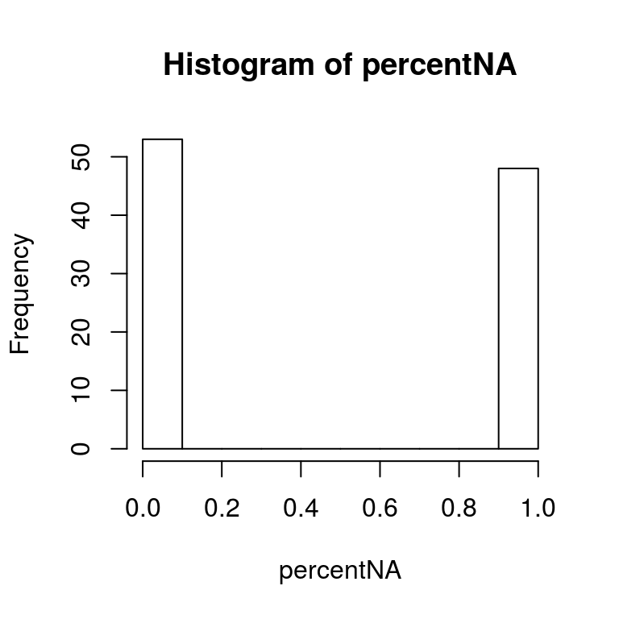

```r
noNA <- sapply(training, function(x) mean(is.na(x)))==0
training <- training[, noNA]
testing  <- testing[, noNA]
```

We will use all remaining variables to build the model.

## Bulding a predictive model

We apply a random forest model, since these models are generally regarded as some of the best for classification problems. We choose options for cross-validation and number is three times

```r
set.seed(332)
mod<-train(classe~., method="rf",data=training,
            trControl=trainControl(method="cv", number=3, verboseIter=FALSE))
```

Looking at the final model:

```r
mod$finalModel
```

```
##
## Call:
##  randomForest(x = x, y = y, mtry = param$mtry)
##                Type of random forest: classification
##                      Number of trees: 500
## No. of variables tried at each split: 2
##
##         OOB estimate of  error rate: 0.87%
## Confusion matrix:
##      A    B    C    D    E  class.error
## A 3346    2    0    0    0 0.0005973716
## B   18 2249   12    0    0 0.0131636683
## C    0   22 2031    1    0 0.0111976631
## D    0    0   42 1887    1 0.0222797927
## E    0    0    2    3 2160 0.0023094688
```

To estimate the expected out of sample error rate we use the testing data set:

```r
pred <- predict(mod, newdata=testing)
confusionMatrix(pred, testing$classe)$overall[1] # extract accuracy only
```

```
##  Accuracy
## 0.9926077
```

## Assignment predictions

Finally predicting using the new data:

```r
predict(mod, newdata=QuizTest)
```

```
##  [1] B A B A A E D B A A B C B A E E A B B B
## Levels: A B C D E
```

Hence our assignment predictions are: B A B A A E D B A A B C B A E E A B B B